# R Notebook with codes for analysis in *Exploring diachronic salience of emotion metaphors*: *A contrastive study of HAPPINESS metaphors in Classical Malay and Indonesian*

by* [I Made Rajeg](https://udayananetworking.unud.ac.id/lecturer/1817-i-made-rajeg) & [Gede Primahadi Wijaya Rajeg](https://udayananetworking.unud.ac.id/lecturer/880-gede-primahadi-wijaya-rajeg)

```r
knitr::opts_chunk$set(fig.width = 6,
                      fig.asp = 0.618,
                      dpi = 600,
                      echo = TRUE,
                      message = FALSE)

# tidyverse suit of packages is required to run the code
library(tidyverse)
# the gridExtra package is required to run the code
library(gridExtra)
# load the `happyr` package (Rajeg 2019) containing the Indonesian data and R functions for the analyses
library(happyr)
```

```r
# load the MCP root database
malay_root_db <- readr::read_tsv("malay_root_db.txt")
## perform some renaming and data pre-processing on the root database
malay_root_db <- malay_root_db %>%
  mutate(syntax = tolower(syntax),
         syntax = str_replace(syntax, 'unsure', 'widlii'),
         syntax = str_replace(syntax, '^dup$', 'duplicate'),
         period_short = str_replace(period, '(..s$)', '00s'),
         genre = if_else(str_detect(genre, '^let') == TRUE, 'letters_&_documents', genre),
         genre = if_else(str_detect(genre, '^prose') == TRUE, 'prose', genre),
         genre = if_else(str_detect(genre, '^tracts') == TRUE, 'tracts_&_manuals', genre),
         genre = if_else(str_detect(genre, '^news') == TRUE, 'newspapers', genre),
         period = str_replace(period, 's$', ''),
         period = as.double(period))

# load the MCP nominalised ke- -an forms database
malay_nominalised_db <- readr::read_tsv("malay_nominalised_db.txt")
# load the MCP combined database of root and nominalised ke- -an forms
malay_combined_db <- readr::read_tsv("malay_combined_db.txt")
# load the MCP metaphor data
malaymeta <- readr::read_tsv("malaymeta.txt")
```

# Compute the distribution of the syntax of the root (nominal vs. others)

```r
malay_root_syntax <- malay_root_db %>%
  count(syntax, words) %>%
  mutate(syntax_short = if_else(syntax %in% c('nominal'), 'nominal', 'misc.')) %>%
  select(words, syntax, syntax_short, n) %>%
  arrange(words, syntax_short, n)
```

The codes below are for generating Table 2 in the manuscript: *Analyzed tokens for the HAPPINESS nouns in MCP*

```r
## root tokens in MCP
malay_root_tokens <- malay_root_syntax %>%
  # when activated, the code below will exclude duplicates, proper names, unclear cases)
  # filter(!str_detect(syntax, "dfm|dup|proper|widlii")) %>%
  group_by(words, syntax_short) %>%
  summarise(n = sum(n), .groups = "drop") %>%
  spread(key = syntax_short, value = n, fill = 0) %>%
  ungroup() %>%
  mutate(tokens = misc. + nominal) %>%
  rename(root_others = misc., root_nominal = nominal) %>%
  select(words, tokens, root_nominal, root_others)
```

```r
## nominalised tokens in MCP
malay_nominalised_tokens <- malay_nominalised_db %>%
  count(words) %>%
  rename(nominalised = n)
```

```r
## cross-tab for total tokens of the HAPPINESS concepts in ke-an and root-nominal form
malay_analysed_tokens <- malay_root_tokens %>%
  full_join(malay_nominalised_tokens, by = "words") %>%
  replace_na(list(nominalised = 0)) %>%
  mutate(sum_analysed_nominal = root_nominal + nominalised)

malay_analysed_tokens_tidy <- malay_analysed_tokens %>%
  select(-tokens, -sum_analysed_nominal) %>%
  gather(use, n, -words) %>%
  mutate(words = if_else(use == "nominalised",
                         paste("ke", words, "an", sep = ""),
                         words))

malay_tb_2 <- malay_analysed_tokens %>%
  select(Concepts = words,
         `Root tokens` = tokens,
         `Root-nominal` = root_nominal,
         `*ke*- -*an* tokens` = nominalised,
         `Total analysed tokens (Root-nominal + *ke*- -*an*)` = sum_analysed_nominal)
malay_tb_2 %>% knitr::kable(caption = "The analyzed tokens for the HAPPINESS nouns in MCP.")
```

The analyzed tokens for the HAPPINESS nouns in MCP.

| Concepts | Root tokens | Root-nominal | *ke*- -*an* tokens | Total analysed tokens (Root-nominal + *ke*- -*an*) |
| --- | --- | --- | --- | --- |
| bahagia | 174 | 95 | 38 | 133 |
| ceria | 4 | 0 | 0 | 0 |
| gembira | 96 | 9 | 3 | 12 |
| riang | 30 | 2 | 5 | 7 |
| senang | 668 | 81 | 298 | 379 |

```r
# uncomment the code below to save the table
# malay_tb_2 %>% write_delim(path = "table_2.txt", delim = "\t")
```

# Genre distribution of the MCP corpus

```r
totals_by_text <- readr::read_tsv('totals_by_texts.txt')
totals_by_text1 <- totals_by_text %>%
  rename(genre = classification) %>%
  group_by(genre) %>%
  summarise(n = sum(words), .groups = "drop") %>%
  mutate(prop = round(n/sum(n) * 100, 2)) %>%
  arrange(desc(prop))
totals_by_text1
```

| genre | n | prop |
| --- | --- | --- |
| prose | 3981802 | 67.61 |
| newspapers | 648651 | 11.01 |
| letters-and-documents | 553427 | 9.40 |
| verse texts | 524602 | 8.91 |
| tracts-and-manuals | 181026 | 3.07 |

```r
total_mcp <- sum(totals_by_text1$n)
total_mcp
```

```
[1] 5889508
```

# Calculating the normalised frequencies of the HAPPINESS words per periods

Preparing the datasets.

```r
# corpus freq per periods
corpus_freq <- readr::read_tsv("malay_period_size.txt")
malay_periods_words_genres_freq <- readr::read_tsv("malay_periods_words_genres_freq.txt")
lexemes_freq <-
  malay_periods_words_genres_freq %>%
  mutate(lexemes = if_else(form == "nominalised",
                           paste("ke", words, "an", sep = ""),
                           words)) %>%
  count(period_range, lexemes) %>%
  rename(periods = period_range)

lexemes_norm_freq <- left_join(lexemes_freq, corpus_freq,
                               by = "periods") %>%
  filter(!is.na(lexemes)) %>%
  mutate(norm_n = round((n/corp_freq) * 1000000, 2))
```

# Generating revised line plot (Figure 1 in the revised manuscript)

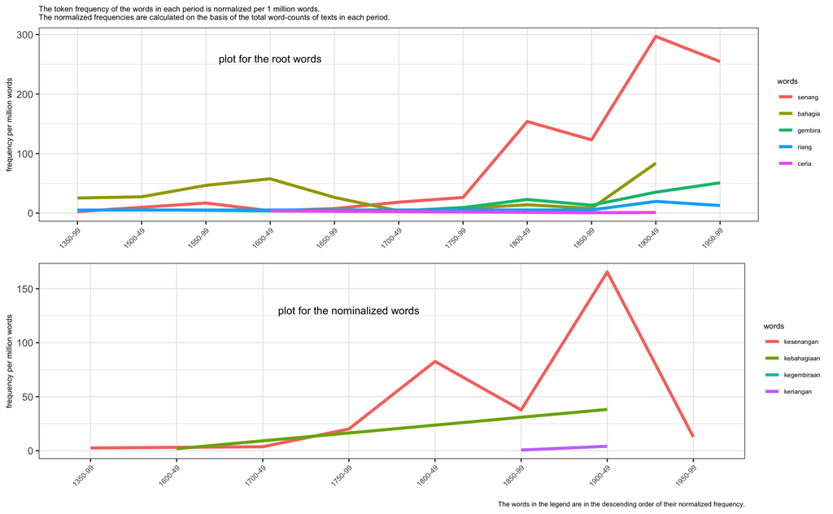

```r
## REVISED: Line plot for Figure 3 (Figure 1 in the revised manuscript) in the Review of Cognitive Linguistics manuscript (1st submitted draft) =======
# tutorial for combining ggplot2 plots (https://towardsdatascience.com/combining-multiple-ggplot2-plots-for-scientific-publications-7dd9908ebe5c)
lexemes_norm_freq_1 <- lexemes_norm_freq %>%
  mutate(morphtype = if_else(str_detect(lexemes, "^ke.+an$"), "ke- -an", "root"))

# plot the root first
linep_root <- lexemes_norm_freq_1 %>%
  filter(morphtype == "root") %>%
  mutate(lexemes = factor(lexemes,
                          levels = c("senang", "bahagia", "gembira", "riang", "ceria"))) %>%
  ggplot(aes(x = periods, y = norm_n, colour = lexemes, group = lexemes)) +
  geom_line(size = 1.5) +
  theme_bw(base_size = 13) +
  theme(axis.text.x = element_text(angle = 45,
                                   vjust = 1,
                                   hjust = 1,
                                   size = 7.5)) +
  labs(x = NULL,
       subtitle = 'The token frequency of the words in each period is normalized per 1 million words.\nThe normalized frequencies are calculated on the basis of the total word-counts of texts in each period.',
       colour = 'words',
       y = 'frequency per million words') +
  theme(plot.subtitle = element_text(size =8),
        plot.caption = element_text(size = 7),
        axis.title.y = element_text(size = 8),
        legend.title = element_text(size = 8),
        legend.text = element_text(size = 6.5)) +
  annotate(geom = "text", x = 4, y = 260, label = "plot for the root words")

# plot the ke- -an types
linep_nominalised <- lexemes_norm_freq_1 %>%
  filter(morphtype == "ke- -an") %>%
  mutate(lexemes = factor(lexemes,
                          levels = c("kesenangan", "kebahagiaan", "kegembiraan", "keriangan"))) %>%
  ggplot(aes(x = periods, y = norm_n, colour = lexemes, group = lexemes)) +
  geom_line(size = 1.5) +
  theme_bw(base_size = 13) +
  theme(axis.text.x = element_text(angle = 45,
                                   vjust = 1,
                                   hjust = 1,
                                   size = 7.5)) +
  labs(x = NULL,
       colour = 'words',
       caption = '\nThe words in the legend are in the descending order of their normalized frequency.',
       y = 'frequency per million words') +
  theme(plot.subtitle = element_text(size =8),
        plot.caption = element_text(size = 7),
        axis.title.y = element_text(size = 8),
        legend.title = element_text(size = 8),
        legend.text = element_text(size = 6.5)) +
  annotate(geom = "text", x = 4, y = 130, label = "plot for the nominalized words")
p_line <- grid.arrange(linep_root, linep_nominalised, nrow = 2)
```

```r
p_line
```

| z | cells | name | grob |
| --- | --- | --- | --- |
| 1 | (1-1,1-1) | arrange | gtable[layout] |
| 2 | (2-2,1-1) | arrange | gtable[layout] |

```r
# uncomment the code below to save the plot
# ggsave(plot = p_line, "RAJ3-1.png", height = 7, width = 6.5, dpi = 600)
# ggsave(plot = p_line, "Figure1.tiff", height = 7, width = 6.5, dpi = 300, device = "tiff") #accepted manuscript
```

# Analysis for the token and type frequency of the *Malay Concordance Project* (MCP) data

```r
ttr_malay <- ttr(malaymeta, "METAPHORS", "LEXICAL_UNIT")
```

Counting the number of conceptual metaphor types in MCP.

```r
length(ttr_malay$metaphors)
```

```
[1] 38
```

# Analysis for the token and type frequency of the Indonesian data

```r
ttr_indo <- ttr(happyr::phd_data_metaphor, "metaphors", "lu")
```

Counting the number of conceptual metaphor types in Indonesian.

```r
length(ttr_indo$metaphors)
```

```
[1] 62
```

# Print out the table for top-10 metaphors in MCP in terms of their token frequency

```r
# entrenched metaphor
entrench_malay <- arrange(top_n(ttr_malay, 10, token), desc(token))
entrench_malay_top10 <- select(entrench_malay, metaphors, token, percentage = perc_token)
knitr::kable(mutate(entrench_malay_top10, metaphors = happyr::scaps(metaphors)), caption = "Top-10 metaphors with high token frequency in MCP", row.names = TRUE)
```

Top-10 metaphors with high token frequency in MCP

|  | metaphors | token | percentage |
| --- | --- | --- | --- |
| 1 | happiness is a possessable object | 160 | 37.56 |
| 2 | happiness is a desired goal | 43 | 10.09 |
| 3 | happiness is a located object | 34 | 7.98 |
| 4 | happiness is a location | 32 | 7.51 |
| 5 | intensity of happiness is quantity of object | 32 | 7.51 |
| 6 | happiness is a contained entity | 15 | 3.52 |
| 7 | happiness is food | 14 | 3.29 |
| 8 | happiness is up | 11 | 2.58 |
| 9 | happiness is an imperilled entity | 9 | 2.11 |
| 10 | happiness is a moving object | 8 | 1.88 |

# Print out the table for top-10 metaphors in Indonesian in terms of their token frequency

```r
# entrenched metaphor
entrench_indo <- arrange(top_n(ttr_indo, 10, token), desc(token))
entrench_indo_top10 <- select(entrench_indo, metaphors, token, percentage = perc_token)
knitr::kable(rename(mutate(entrench_indo_top10, metaphors = happyr::scaps(metaphors)), `% of token` = percentage), caption = "Top-10 metaphors with high token frequency in Indonesian", row.names = TRUE)
```

Top-10 metaphors with high token frequency in Indonesian

|  | metaphors | token | % of token |
| --- | --- | --- | --- |
| 1 | happiness is a possessable object | 749 | 20.59 |
| 2 | happiness is a contained entity | 358 | 9.84 |
| 3 | happiness is a desired goal | 293 | 8.05 |
| 4 | happiness is an (un)veiled object | 211 | 5.80 |
| 5 | happiness is a located object | 210 | 5.77 |
| 6 | happiness is a location | 169 | 4.65 |
| 7 | happiness is a liquid in a container | 156 | 4.29 |
| 8 | intensity of happiness is quantity of object | 137 | 3.77 |
| 9 | happiness is food | 108 | 2.97 |
| 10 | happiness is a submerged entity | 99 | 2.72 |

# Combining the top-10 MCP and Indonesian data for high-token frequency metaphors

```r
entrench_indo_top10$lang <- "indonesian"
entrench_malay_top10$lang <- "malay"
entrench_malayindo_top10 <- full_join(entrench_indo_top10,
                                      entrench_malay_top10)
entrench_malayindo_top10 <- mutate(entrench_malayindo_top10,
                                   metaphors = str_replace_all(
                                     metaphors,
                                     "^(intensity of )?happiness is( a(n)?)?", ""))
```

# Plotting Figure 2 in the paper (Section 3.1)

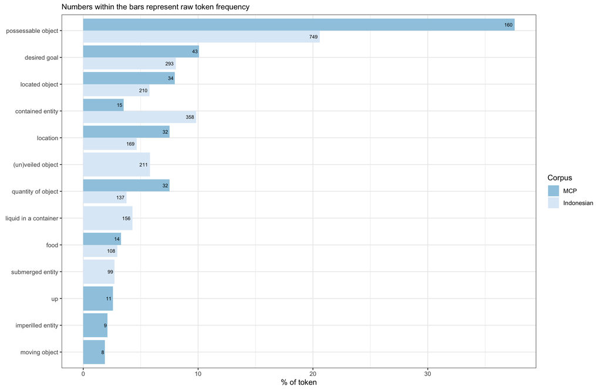

```r
entrench_joint_plot <- entrench_malayindo_top10 %>%
  ggplot(aes(x = reorder(metaphors, percentage),
             y = percentage,
             fill = lang)) +
  geom_col(position = "dodge") +
  coord_flip() +
  scale_fill_brewer(name = "Corpus",
                    breaks = c("malay", "indonesian"),
                    labels = c("MCP", "Indonesian")) +
  theme_bw() +
  geom_text(aes(label = token), position = position_dodge(width = 0.9), size = 2.5, hjust = 1.25) +
  labs(x = NULL,
       fill = "corpus",
       y = "% of token",
       subtitle = "Numbers within the bars represent raw token frequency")
entrench_joint_plot
```

```r
# uncomment the code below to save the plot
# entrench_joint_plot + ggsave("RAJ4.png", height = 4.5, width = 6.5, dpi = 600)
# entrench_joint_plot + ggsave("Figure2.tiff", height = 4.5, width = 6.5, dpi = 300, device = "tiff") # accepted manuscript
```

## Get the information on the (dominant) source frames in the POSSESSABLE OBJECT metaphor

```r
poss_frame <- happyr::get_frames("possessable", df = malaymeta, frame_var = "METANET_SOURCE_FRAMES", metaphor_var = "METAPHORS", lexunit_var = "LEXICAL_UNIT")
```

The two prominent frames in terms of their token and type frequencies are GAIN POSSESSION (N = 83; Type = 9) and TRANSFER SCENARIO (N = 58; Type = 12).

```r
goal_frame_malay <- happyr::get_frames("desired goal$", df = malaymeta, frame_var = "METANET_SOURCE_FRAMES", metaphor_var = "METAPHORS", lexunit_var = "LEXICAL_UNIT")
goal_submet_malay <- happyr::get_submappings("desired", df = malaymeta, metaphor_var = "METAPHORS", submet_var = "SUBMET", lexunit_var = "LEXICAL_UNIT")
goal_frame_indo <- happyr::get_frames("desired goal", df = happyr::phd_data_metaphor)
```

The most predominant MOTION frame is PURSUE (N = 18; Type = 3)

## Codes for discussing the LOCATION-based conceptualizations of HAPPINESS

```r
malay_location_frames <- get_frames("is a location",
                                    df = malaymeta,
                                    metaphor_var = "METAPHORS",
                                    frame_var = "METANET_SOURCE_FRAMES",
                                    lexunit_var = "LEXICAL_UNIT")

malay_location_frames <- mutate(malay_location_frames,
                                frames = replace(frames,
                                                 frames == "BOUNDED REGION",
                                                 "BEING IN A BOUNDED REGION"))

malay_location_frames <- malay_location_frames %>%
  group_by(frames) %>%
  summarise(n = sum(n),
            type = sum(type),
            perc = sum(perc),
            type_perc = sum(type_perc)) %>%
  arrange(desc(n))
```

In Malay, frame with highest token frequency motivating the LOCATION mapping is the BOUNDED REGION (N = 19; Type = 3)

# Print out the table for top-10 metaphors in MCP in terms of their type frequency

```r
prod_malay <- arrange(top_n(ttr_malay, 10, type_lu), desc(type_lu))
prod_malay_top10 <- select(prod_malay, metaphors, token, type = type_lu, percentage_type = perc_type_lu)
knitr::kable(rename(mutate(prod_malay_top10, metaphors = happyr::scaps(metaphors)), `% of type` = percentage_type), caption = "Top-10 metaphors with high type frequency in MCP", row.names = TRUE)
```

Top-10 metaphors with high type frequency in MCP

|  | metaphors | token | type | % of type |
| --- | --- | --- | --- | --- |
| 1 | happiness is a possessable object | 160 | 26 | 15.48 |
| 2 | intensity of happiness is quantity of object | 32 | 15 | 8.93 |
| 3 | happiness is a desired goal | 43 | 13 | 7.74 |
| 4 | happiness is a location | 32 | 12 | 7.14 |
| 5 | happiness is a located object | 34 | 10 | 5.95 |
| 6 | happiness is up | 11 | 8 | 4.76 |
| 7 | happiness is a contained entity | 15 | 7 | 4.17 |
| 8 | happiness is a moving object | 8 | 7 | 4.17 |
| 9 | happiness is an imperilled entity | 9 | 6 | 3.57 |
| 10 | happiness is food | 14 | 5 | 2.98 |
| 11 | happiness is a plant | 5 | 5 | 2.98 |

# Print out the table for top-10 metaphors in Indonesian in terms of their type frequency

```r
prod_indo <- arrange(top_n(ttr_indo, 10, type_lu), desc(type_lu))
prod_indo_top10 <- select(prod_indo, metaphors, token, type = type_lu, percentage_type = perc_type_lu)
knitr::kable(rename(mutate(prod_indo_top10, metaphors = happyr::scaps(metaphors)), `% of type` = percentage_type), caption = "Top-10 metaphors with high type frequency in Indonesian", row.names = TRUE)
```

Top-10 metaphors with high type frequency in Indonesian

|  | metaphors | token | type | % of type |
| --- | --- | --- | --- | --- |
| 1 | happiness is a possessable object | 749 | 63 | 7.84 |
| 2 | happiness is a desired goal | 293 | 42 | 5.22 |
| 3 | happiness is a liquid in a container | 156 | 37 | 4.60 |
| 4 | happiness is a location | 169 | 35 | 4.35 |
| 5 | intensity of happiness is quantity of object | 137 | 29 | 3.61 |
| 6 | happiness is light | 43 | 27 | 3.36 |
| 7 | happiness is a contained entity | 358 | 26 | 3.23 |
| 8 | happiness is a located object | 210 | 26 | 3.23 |
| 9 | happiness is an (un)veiled object | 211 | 23 | 2.86 |
| 10 | happiness is an imperilled entity | 32 | 21 | 2.61 |

# Combining the top-10 MCP and Indonesian data for high-type frequency metaphors

```r
prod_indo_top10$lang <- "indonesian"
prod_malay_top10$lang <- "malay"
prod_malayindo_top10 <- full_join(prod_indo_top10,
                                      prod_malay_top10)
prod_malayindo_top10 <- mutate(prod_malayindo_top10,
                                   metaphors = str_replace_all(
                                     metaphors,
                                     "^(intensity of )?happiness is( a(n)?)?", ""))
```

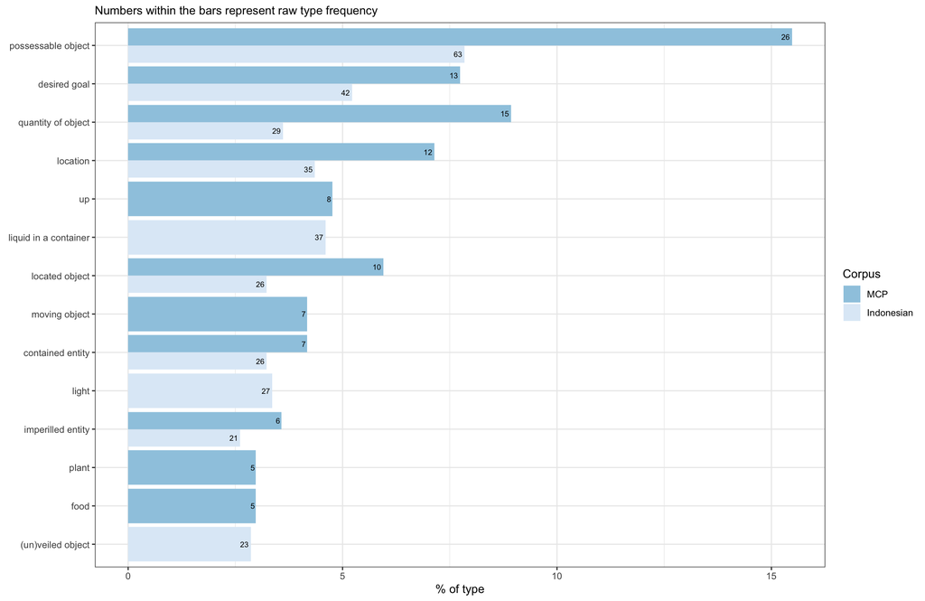

```r
prod_joint_plot <- prod_malayindo_top10 %>%
  ggplot(aes(x = reorder(metaphors, percentage_type),
             y = percentage_type,
             fill = lang)) +
  geom_col(position = "dodge") +
  coord_flip() +
  scale_fill_brewer(name = "Corpus",
                    breaks = c("malay", "indonesian"),
                    labels = c("MCP", "Indonesian")) +
  theme_bw() +
  geom_text(aes(label = type), position = position_dodge(width = 0.9), size = 2.5, hjust = 1.25) +
  labs(x = NULL,
       fill = "corpus",
       y = "% of type",
       subtitle = "Numbers within the bars represent raw type frequency")
prod_joint_plot
```

```r
# uncomment the code below to save the plot
# prod_joint_plot + ggsave("RAJ5.png", height = 4.5, width = 6.5, dpi = 600)
# prod_joint_plot + ggsave("Figure3.tiff", height = 4.5, width = 6.5, dpi = 300, device = "tiff") # accepted manuscript
```

Notes on the PLANT metaphor